# Practical Machine Learning PA Project

Roberto Aviles (rlaviles)

Saturday, July 25, 2015

### Weight Lifting Exercise Prediction Using Human Activity Recognition (HAR) Data

#### Abstract

The objective of this work is to predict the way an exercise has been performed by using the ‘classe’ variable in the training dataset collected by the HAR project, part of Groupware@LES, “a research and development group on technologies for team work”, in Universidad Catolica de Rio de Janeiro, Brasil. In this dataset, a group of 6 people has been asked to perform barbell lifts in 5 diferent ways, the right one and 4 wrong ones. One goal was to teach people how to workout the right way, for both health reasons and as better use of their time.

1. About the Data.  
   Training and Testing are matrices of (19622,160) and (20,160) {rows, columns} respectively. After inspection, we can discard columns like X, raw_timestamp_part_1, raw_timestamp_part_2, cvtd_timestamp. There are many NA values and also, many ‘zero or near zero variance’ predictors. Now we load libraries and start preparing the data:

```r
library(caret); library(knitr); library(plyr)
DTraining<-read.csv("pml-training.csv", stringsAsFactors=FALSE) # load training and testing datasets
DTesting<-read.csv("pml-testing.csv", stringsAsFactors=FALSE)
dtraining<-subset(DTraining, select = -c(X,raw_timestamp_part_1, raw_timestamp_part_2, cvtd_timestamp))
nzv<-nearZeroVar(dtraining, saveMetrics=TRUE)
nzv<-subset(nzv, nzv==TRUE)     # a subset of 60 columns of the original data
dtraining<-subset(dtraining, select = !names(dtraining) %in% rownames(nzv))
dNA<-function(vector){ return(sum(is.na(vector))) }
NAnum<-sapply(dtraining, dNA)
noNA<-names(NAnum[NAnum / nrow(dtraining) == 0])
dtraining<-subset(dtraining, select = names(dtraining) %in% noNA)
print(matrix(noNA,ncol=5))  # the remaining useful columns of information after 'cleaning'.
```

```
##       [,1]               [,2]              [,3]
##  [1,] "user_name"        "accel_belt_z"    "accel_arm_x"
##  [2,] "num_window"       "magnet_belt_x"   "accel_arm_y"
##  [3,] "roll_belt"        "magnet_belt_y"   "accel_arm_z"
##  [4,] "pitch_belt"       "magnet_belt_z"   "magnet_arm_x"
##  [5,] "yaw_belt"         "roll_arm"        "magnet_arm_y"
##  [6,] "total_accel_belt" "pitch_arm"       "magnet_arm_z"
##  [7,] "gyros_belt_x"     "yaw_arm"         "roll_dumbbell"
##  [8,] "gyros_belt_y"     "total_accel_arm" "pitch_dumbbell"
##  [9,] "gyros_belt_z"     "gyros_arm_x"     "yaw_dumbbell"
## [10,] "accel_belt_x"     "gyros_arm_y"     "total_accel_dumbbell"
## [11,] "accel_belt_y"     "gyros_arm_z"     "gyros_dumbbell_x"
##       [,4]                [,5]
##  [1,] "gyros_dumbbell_y"  "total_accel_forearm"
##  [2,] "gyros_dumbbell_z"  "gyros_forearm_x"
##  [3,] "accel_dumbbell_x"  "gyros_forearm_y"
##  [4,] "accel_dumbbell_y"  "gyros_forearm_z"
##  [5,] "accel_dumbbell_z"  "accel_forearm_x"
##  [6,] "magnet_dumbbell_x" "accel_forearm_y"
##  [7,] "magnet_dumbbell_y" "accel_forearm_z"
##  [8,] "magnet_dumbbell_z" "magnet_forearm_x"
##  [9,] "roll_forearm"      "magnet_forearm_y"
## [10,] "pitch_forearm"     "magnet_forearm_z"
## [11,] "yaw_forearm"       "classe"
```

2. Next steps:
- **preprocess** the data
- **partitionate** it and
- do a **preliminary check** of the Training subset

```r
preProVals <-preProcess(dtraining[,-c(1,55)], method = c("center", "scale"))
preProVals$user_name <- dtraining$user_name
preProVals$classe <- dtraining$classe
toTrain <- createDataPartition(preProVals$classe, p=0.75, list=F) #p = default value.check it!
training<-dtraining[toTrain,]
testing<-dtraining[-toTrain]
```

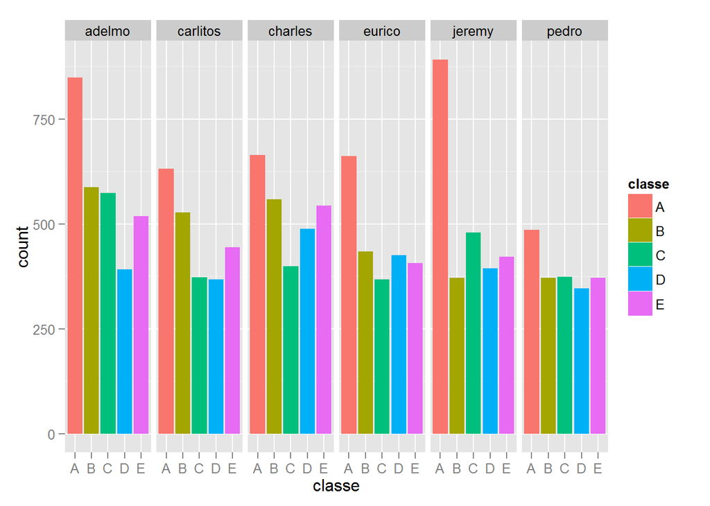

```r
ggplot(training, aes(x = classe, fill = classe)) + geom_bar(aes(classe)) + facet_grid(.~user_name)
```

```r
library(randomForest); library(kernlab); library(klaR)
training$classe <- as.factor(training$classe)
cvControl <-trainControl(method = "cv", number = 5, allowParallel = TRUE, verboseIter = TRUE)
model1 <- train(classe ~., training, method = "rf", trControl = cvControl) #model with random forest
model2 <- train(classe ~., training, method = "svmRadial", trControl = cvControl) # model with radial SVM
model3 = train(classe ~., training, method = "knn", trControl = cvControl)
model4 = train(classe ~., training, method = "nb", trControl = cvControl)
```

```r
model1[4]; model1[11]
```

```
## $results
##   mtry  Accuracy     Kappa   AccuracySD     KappaSD
## 1    2 0.9938171 0.9921785 0.0014086760 0.001781515
## 2   30 0.9972142 0.9964762 0.0009429438 0.001193067
## 3   58 0.9936812 0.9920071 0.0019160514 0.002423951
```

```
## $finalModel
##
## Call:
##  randomForest(x = x, y = y, mtry = param$mtry)
##                Type of random forest: classification
##                      Number of trees: 500
## No. of variables tried at each split: 30
##
##         OOB estimate of  error rate: 0.22%
## Confusion matrix:
##      A    B    C    D    E  class.error
## A 4184    1    0    0    0 0.0002389486
## B    7 2836    4    1    0 0.0042134831
## C    0    6 2561    0    0 0.0023373588
## D    0    0    7 2404    1 0.0033167496
## E    0    1    0    4 2701 0.0018477458
```

```r
model2[4]; model2[11]
```

```
## $results
##        sigma    C  Accuracy     Kappa  AccuracySD     KappaSD
## 1 0.01174385 0.25 0.8688681 0.8342002 0.004023541 0.005183003
## 2 0.01174385 0.50 0.9043351 0.8788745 0.003217659 0.004124142
## 3 0.01174385 1.00 0.9319882 0.9138562 0.002291787 0.002942151
```

```
## $finalModel
## Support Vector Machine object of class "ksvm"
##
## SV type: C-svc  (classification)
##  parameter : cost C = 1
##
## Gaussian Radial Basis kernel function.
##  Hyperparameter : sigma =  0.0117438478139355
##
## Number of Support Vectors : 7090
##
## Objective Function Value : -1051.113 -805.3369 -744.9408 -428.5018 -1015.412 -558.2042 -656.9748 -1079.438 -666.0021 -594.2111
## Training error : 0.055714
```

```r
model3[4]; model3[11]
```

```
## $results
##   k  Accuracy     Kappa  AccuracySD     KappaSD
## 1 5 0.9020248 0.8760225 0.003861991 0.004865511
## 2 7 0.8857183 0.8553788 0.004363310 0.005537797
## 3 9 0.8700233 0.8355652 0.005465978 0.006895857
```

```
## $finalModel
## 5-nearest neighbor classification model
## Training set class distribution:
##
##    A    B    C    D    E
## 4185 2848 2567 2412 2706
```

```r
model4[4]
```

```
## $results
##   usekernel fL  Accuracy     Kappa AccuracySD    KappaSD
## 1     FALSE  0 0.5576169 0.4427306 0.01162287 0.01431810
## 2      TRUE  0 0.7554013 0.6920216 0.01361968 0.01697867
```

I have measured the CPU time requested to run each model: Random Forest, 20 minutes; radial SVM, 12 minutes; k Nearest Neighbour, 2 minutes; Naive Bayes, 5 minutes (a number of warings have been ‘discarded’ since my objective was only to test NB, not to use it.) And now, check the results (in terms of accuracy) for these 4 models:

```r
accuracy <- data.frame(Model=c("Random Forest", "SVM (radial)", "KNN", "Naive Bayes"),
                       Accuracy=c(round(max(head(model1$results)$Accuracy), 5),
                                   round(max(head(model2$results)$Accuracy), 5),
                                   round(max(head(model3$results)$Accuracy), 5),
                                   round(max(head(model4$results)$Accuracy),5)))
accuracy
```

```
##           Model Accuracy
## 1 Random Forest  0.99721
## 2  SVM (radial)  0.93199
## 3           KNN  0.90202
## 4   Naive Bayes  0.75540
```

```r
DTesting <- DTesting[, names(DTesting) %in% names(training)]
testmodelRF <- predict(model1, DTesting)
testmodelSVM<- predict(model2, DTesting)
testmodelKNN<- predict(model3, DTesting)
testmodelBN<- predict(model4, DTesting)
## Construct a table and check if the models agree in their predictions
predTable <- data.frame(rfPred = testmodelRF, svmPred = testmodelSVM, knnPred = testmodelKNN, bnPred = testmodelBN)
predTable$agree <- with(predTable, rfPred == svmPred && rfPred == knnPred && rfPred == bnPred)
Agreement <- all(predTable$agree)

kable(predTable)  ## an ordered summary of results
```

| rfPred | svmPred | knnPred | bnPred | agree |
| --- | --- | --- | --- | --- |
| B | B | B | C | FALSE |
| A | A | A | A | FALSE |
| B | A | B | A | FALSE |
| A | A | A | A | FALSE |
| A | A | A | A | FALSE |
| E | E | E | E | FALSE |
| D | D | D | D | FALSE |
| B | B | B | C | FALSE |
| A | A | A | A | FALSE |
| A | A | A | A | FALSE |
| B | B | B | A | FALSE |
| C | C | C | A | FALSE |
| B | B | B | B | FALSE |
| A | A | A | A | FALSE |
| E | E | E | E | FALSE |
| E | E | E | B | FALSE |
| A | A | A | A | FALSE |
| B | B | B | B | FALSE |
| B | B | B | B | FALSE |
| B | B | B | B | FALSE |

```r
## table(predTable)  ## a bit more of details
```

```r
DTesting <- DTesting[, names(DTesting) %in% names(training)]
testmodelRF <- predict(model1, DTesting)
testmodelSVM<- predict(model2, DTesting)
testmodelKNN<- predict(model3, DTesting)
## Construct a table and check if the models agree in their predictions
predTable <- data.frame(rfPred = testmodelRF, svmPred = testmodelSVM, knnPred = testmodelKNN)
predTable$agree <- with(predTable, rfPred == svmPred && rfPred == knnPred)
Agreement <- all(predTable$agree)

kable(predTable)  ## an ordered summary of results
```

| rfPred | svmPred | knnPred | agree |
| --- | --- | --- | --- |
| B | B | B | TRUE |
| A | A | A | TRUE |
| B | A | B | TRUE |
| A | A | A | TRUE |
| A | A | A | TRUE |
| E | E | E | TRUE |
| D | D | D | TRUE |
| B | B | B | TRUE |
| A | A | A | TRUE |
| A | A | A | TRUE |
| B | B | B | TRUE |
| C | C | C | TRUE |
| B | B | B | TRUE |
| A | A | A | TRUE |
| E | E | E | TRUE |
| E | E | E | TRUE |
| A | A | A | TRUE |
| B | B | B | TRUE |
| B | B | B | TRUE |
| B | B | B | TRUE |

```r
## table(predTable)  ## too much detail, I decided not to show this!
```

Now we are ready to submit our results, considering only our Random Forest model. Final remarks: we have taken up to a 75% (p=0.75) of data for training and have tested the dataset with 4 different methods/models. After test, we have discarded only Naive Bayes and probed that Random Forest with cross validation is the better method for the construction of a good model (higher accuracy.)

References:  
1. https://www.unt.edu/rss/class/Jon/Benchmarks/CrossValidation1_JDS_May2011.pdf  
2. http://www.r-bloggers.com/near-zero-variance-predictors-should-we-remove-them  
3. https://cran.r-project.org/web/packages/caret/vignettes/caret.pdf NEW!  
4. https://cran.r-project.org/web/views/MachineLearning.html  
5. https://cran.r-project.org/web/packages/klaR/index.html  
(I am really sorry that I was unable (time!) to find the right way to eliminate (not to show) ‘useless’ lines.)